# Aula Extra - Regressão

## Créditos:

- Esta aula foi baseado nos materias disponibilizados por [Just Markham](https://github.com/justmarkham/scikit-learn-videos).

```python
#comando para habilitar o autocomplete:
%config IPCompleter.greedy=True
```

```python
import pandas as pd

#ler o CSV e usa a primeira coluna como index
data = pd.read_csv('Advertising.csv', index_col=0)
data.head()
```

|  | TV | Radio | Newspaper | Sales |
| --- | --- | --- | --- | --- |
| 1 | 230.1 | 37.8 | 69.2 | 22.1 |
| 2 | 44.5 | 39.3 | 45.1 | 10.4 |
| 3 | 17.2 | 45.9 | 69.3 | 9.3 |
| 4 | 151.5 | 41.3 | 58.5 | 18.5 |
| 5 | 180.8 | 10.8 | 58.4 | 12.9 |

### Atributos utilizados

- TV: custo em milhares de dolars com propaganda na TV
- Radio: custo propaganda no Rádio
- Newspaper: custo propaganda em jornais;

### Target

- Sales: venda de um produto em um dado mercado

Como o target é contínuo, então estamos lidando com um problema de **regressão**.

## Visualizando os dados usando o seaborn

Seaborn é uma biblioteca construída sobre o matplotlib. Ela é utilizada para a visualização de dados estatísticos.

```python
import seaborn as sns

%matplotlib inline
```

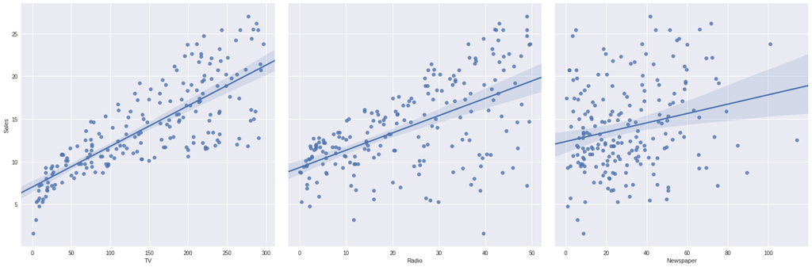

```python
sns.pairplot(data, x_vars=['TV', 'Radio', 'Newspaper'], y_vars='Sales', size=7, kind='reg')
```

## Regressão Linear

A regressão linear encontrar uma reta que melhor se encaixe aos dados.

- Prós: rápida, facilmente interpretável;
- Contras: se os dados possuiem uma relação não-linear, então este algoritmo não será útil.

Forma da Regressão Linear:  
$ f(x_1, ..., x_n) = \beta_0 + \beta_1x_1 + ... + \beta_nx_n $

Chamaremos $f(x_1, ..., x_n)$ de $y$.

- $y$ é a resposta (target);
- $\beta_0$ é o coeficiente de intercepção;
- $\beta_1$ é o coeficiente para o $x_1$ (primeiro atributo)
- $\beta_n$ é o coeficiente para o $x_n$ (n-ésimo atributo)

Para a base de dados utilizada, temos:  
$ f(x_1, ..., x_n) = \beta_0 + \beta_1 \times TV + \beta_2 \times Radio + \beta_3 \times Newspaper $

```python
#separando os atributos dos targets
X = data[['TV', 'Radio', 'Newspaper']]
y = data['Sales']

#divisão de dados para treino e teste
from sklearn.model_selection import train_test_split
#por padrão esta função separa 25% para teste e 75% para trienamento
X_train, X_test, y_train, y_test = train_test_split(X, y, random_state=1)
```

```python
from sklearn.linear_model import LinearRegression

est = LinearRegression()

#treinamento e predição
est.fit(X_train, y_train)
y_pred = est.predict(X_test)
```

## Avaliando o Modelo

Como os targets são contínuos, uma alternativa é somar as diferenças entre o que foi estimado e o valor real, a fim de quantificar o erro da predição. Entretanto, podem aparecer valores positivos e negativas e ao somarmos não teríamos o erro não seria devidamente mensurado. Assim, ao invés de somar as diferenças, somamos o quadrado das diferenças e depois fazamos uma média. Essa técnica é chamada de Mean Squared Error (MSE).  
Uma prática comum é calcular raiz quadrado do MSE, isto é Root Mean Squared Erro (RMSE), pois assim temos uma noção unitária do erro da função.

```python
import numpy as np
from sklearn.metrics import mean_squared_error

print('MSE: ', mean_squared_error(y_test, y_pred))
print('RMSE: ', np.sqrt(mean_squared_error(y_test, y_pred)))
```

```
MSE:  1.97304562023
RMSE:  1.40465142303
```

## Interpretando os coeficientes do modelo

```python
print(est.intercept_)
print(est.coef_)
```

```
2.87696662232
[ 0.04656457  0.17915812  0.00345046]
```

```python
#vamos deixar em pares os nomes dos atributos e os coeficientes obtidos pelo modelo
list(zip([['TV', 'Radio', 'Newspaper'], est.coef_]))
```

```
[(['TV', 'Radio', 'Newspaper'],),
 (array([ 0.04656457,  0.17915812,  0.00345046]),)]
```

**O modelo obtido foi:**

$ y = 2.876966 + 0.04656457 \times TV + 0.17915812 \times Radio + 0.00345046 \times Newspaper $

- Como posso interpretar o **coeficiente TV** (0.0466)?
  - Para uma dada quantidade de propaganda em Radio e Newspaper, uma unidade a mais de propaganda na TV está associada com 0.0466 unidades aumentadas de vendas. Em outras palavras, caso seja gastado 1.000 em propaganda na TV haverá um aumento de venda de 46,6 itens.

Importante:

- Com a regressão podemos observer uma relação existente, como, pro exemplo que ao aumentar propagandas na TV as vendas aumentam. Entretanto essa relação não implica em causa.
- Se um aumento de propaganda em TV estivesse associado com uma diminuição nas vendas, então $\beta_1$ seria negativo;

## Exercício

Tente remover a coluna **'Newspaper'** e faça novamente o treinamento e o teste. Qual foi o RMSE atingido?